# Predicting Absenteeism - Group Assignment 1

In this machine learning project, we use employee records in a two-week period to predict whether or not he/she would be absent for 5 days or more in the next two-week period. This is the output variable. The absentee data from six periods are observed: the first and second halves of June, August and October 2018. It can be inferred from our prediction models, that an employee’s interactions with his/her colleagues and satisfaction during one period may affect his/her attendance in the immediate next period.

```python
import numpy as np
import matplotlib.pyplot as plt
import pandas as pd
from datetime import datetime, timedelta, date

pd.set_option('display.max_rows', 200)

from sklearn import tree
from sklearn.preprocessing import StandardScaler, MinMaxScaler
from sklearn.metrics import accuracy_score, recall_score
from sklearn.model_selection import train_test_split
from sklearn.model_selection import cross_val_score, StratifiedKFold, StratifiedGroupKFold
from sklearn.neighbors import KNeighborsClassifier
from imblearn.under_sampling import RandomUnderSampler
from imblearn.over_sampling import RandomOverSampler
from sklearn.metrics import confusion_matrix, accuracy_score
from sklearn import svm
from sklearn.cluster import KMeans


import matplotlib.pyplot as plt
import seaborn as sns

import warnings
warnings.filterwarnings('ignore')
```

```python
comments = pd.read_csv('comments_by_employees_in_anonymous_forum.csv',
                       sep=',')

interactions = pd.read_csv('commentInteractions.csv',
                           sep=',')

votes = pd.read_csv('votes.csv',sep=',')

absentees = pd.read_csv('employeeAbsenteeism.csv',sep=',')

quit = pd.read_csv('lastParticipationExists.csv',sep=',')
```

# Part 1: Exploratory data analysis

## 1.1 Comments made by an employee

```python
comments.head()
```

|  | employee | companyAlias | commentId | commentLength | likes | dislikes | commentDate | feedbackType |
| --- | --- | --- | --- | --- | --- | --- | --- | --- |
| 0 | aKP | C1 | 5909b33da2ede4000473da6f | 17 | 9 | 0 | 2017-05-03 12:05 | OTHER |
| 1 | dNx | C1 | 5909b6aca2ede4000473da72 | 25 | 12 | 0 | 2017-05-03 12:05 | OTHER |
| 2 | ONv | C1 | 5909c2dea2ede4000473db8c | 58 | 33 | 5 | 2017-05-03 13:05 | OTHER |
| 3 | e9M | C1 | 5909d32ea2ede4000473db97 | 56 | 11 | 4 | 2017-05-03 14:05 | OTHER |
| 4 | RWM | C1 | 5909f227a2ede4000473dcbe | 105 | 18 | 0 | 2017-05-03 17:05 | OTHER |

```python
# Convert date entry into date type, excluding the hours as the exact time is not relevant for our analysis

comments['commentDate'] =pd.to_datetime(comments['commentDate'])
comments.head(1000)
```

|  | employee | companyAlias | commentId | commentLength | likes | dislikes | commentDate | feedbackType |
| --- | --- | --- | --- | --- | --- | --- | --- | --- |
| 0 | aKP | C1 | 5909b33da2ede4000473da6f | 17 | 9 | 0 | 2017-05-03 12:05:00 | OTHER |
| 1 | dNx | C1 | 5909b6aca2ede4000473da72 | 25 | 12 | 0 | 2017-05-03 12:05:00 | OTHER |
| 2 | ONv | C1 | 5909c2dea2ede4000473db8c | 58 | 33 | 5 | 2017-05-03 13:05:00 | OTHER |
| 3 | e9M | C1 | 5909d32ea2ede4000473db97 | 56 | 11 | 4 | 2017-05-03 14:05:00 | OTHER |
| 4 | RWM | C1 | 5909f227a2ede4000473dcbe | 105 | 18 | 0 | 2017-05-03 17:05:00 | OTHER |
| ... | ... | ... | ... | ... | ... | ... | ... | ... |
| 995 | P56 | C1 | 597585f6b3e34e0004d4d284 | 146 | 4 | 9 | 2017-07-24 07:07:00 | OTHER |
| 996 | ADW | C1 | 5975c7f1b3e34e0004d4d2e9 | 79 | 3 | 4 | 2017-07-24 12:07:00 | OTHER |
| 997 | DbY | C1 | 597600edf5717400042b8a37 | 70 | 1 | 4 | 2017-07-24 16:07:00 | OTHER |
| 998 | W73 | C1 | 597618802f31ae00047a022f | 135 | 4 | 12 | 2017-07-24 17:07:00 | OTHER |
| 999 | DAg | C1 | 59761dcafc87200004e65037 | 179 | 3 | 5 | 2017-07-24 18:07:00 | OTHER |

1000 rows × 8 columns

```python
print(comments.dtypes)
```

```
employee                 object
companyAlias             object
commentId                object
commentLength             int64
likes                     int64
dislikes                  int64
commentDate      datetime64[ns]
feedbackType             object
dtype: object
```

Fist we explore the evolution of the number of comments. In order to get a better picture of how comments evolved, we plot the overall comment figures month-on-month. A daily plot would be too granular in order to observe differences in movement. It can be noted that the peak in the number of mothly comments was in the initial period (over 500 comments), while subsequently the number of monhtly comments dropped sharply (below 200) and maintained levels below 300 month on month, until the end of the period. The initial spike may be because employees were enthsuastic about using the platform when it was launched.

```
AxesSubplot(0.125,0.125;0.775x0.755)
```

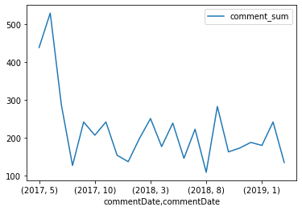

```python
comments.index = comments['commentDate']

monthly_comments = comments.groupby(by=[comments.index.year, comments.index.month]).agg(comment_sum = ('commentId', 'count')).plot(legend=True)
print(monthly_comments)
```

```python
# Count number of unique employees who provided at least one comment
comments['employee'].nunique()
```

```
305
```

```python
# Count number of comments per employee
comments_by_employee = comments.groupby("employee")['commentId'].count().sort_values(ascending=False).reset_index(name ='Total Comments')
print(comments_by_employee)
```

```
    employee  Total Comments
0        4ov             373
1         mw             216
2        ewj             147
3        rLv             124
4        zKG             122
..       ...             ...
300      qN2               1
301      Zwq               1
302       ZB               1
303      7Oj               1
304      gbw               1

[305 rows x 2 columns]
```

```python
# Count average comments per employee
comments_by_employee.mean()
```

```
Total Comments    16.629508
dtype: float64
```

```python
comments_by_employee['Total Comments'].median()
```

```
6.0
```

```python
comments_by_employee['Total Comments'].mode()
```

```
0    1
Name: Total Comments, dtype: int64
```

We now turn our attention to the comment types. There are five categories of comments: "congratulation", "criticisim", "information", "suggestion" and "other". There is no additional information about what the "other" category covers. We break down the comments in categories to better understand what types of comments predominate.

```python
comment_types =  comments.groupby("feedbackType")['commentId'].count().sort_values(ascending=False).reset_index(name ='Total_comment_types')
print(comment_types)
```

```
     feedbackType  Total_comment_types
0           OTHER                 3188
1     INFORMATION                 1302
2  CONGRATULATION                  325
3      SUGGESTION                  241
4       CRITICISM                   16
```

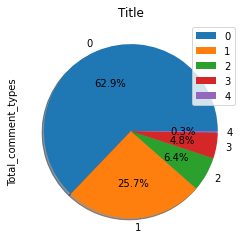

```python
plot = comment_types.plot.pie(y='Total_comment_types', title="Title", legend=True, \
                   autopct='%1.1f%%',
                   shadow=True, startangle=0)
```

It can be noted that the vast majority of comments are in the "other" category (3188), followed by informative comments (1302). In third position are the congratulation comments with 325 and in fourth the suggestion comments with 241. Finally, we note that there are very few comments related to criticism, which could be indicative of a generally high level of satisfaction among employees.

```python
monthly_likes_and_dislikes = pd.DataFrame(comments.groupby(by=[comments.index.year, comments.index.month]).agg(sum_likes = ('likes', 'sum'), sum_dislikes = ('dislikes','sum')))
print(monthly_likes_and_dislikes)
```

```
                         sum_likes  sum_dislikes
commentDate commentDate
2017        5                 4004          1170
            6                 5845          1839
            7                 2565          1671
            8                 1026           441
            9                 3179          1297
            10                2504           973
            11                3252          1484
            12                1775           579
2018        1                 1639           710
            2                 2845          1182
            3                 4068          1521
            4                 3324           842
            5                 6007          1935
            6                 2676           889
            7                 3879          1514
            8                 2005           895
            9                 2751           970
            10                1219           557
            11                2319           875
            12                3026           869
2019        1                 3513           961
            2                 3852          1208
            3                 1736           425
```

```python
monthly_likes_and_dislikes['sum_likes'].mean()
```

```
3000.391304347826
```

```python
monthly_likes_and_dislikes['sum_dislikes'].mean()
```

```
1078.5652173913043
```

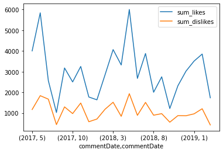

```python
monthly_likes_and_dislikes = pd.DataFrame(comments.groupby(by=[comments.index.year, comments.index.month]).agg(sum_likes = ('likes', 'sum'), sum_dislikes = ('dislikes','sum'))).plot(legend = True)
```

We note that the amount of likes is consistently higher across the whole period (by a significant amount) and that the amounts of likes and dislikes move in tandem. This indicates that generally positive reactions amoung active employees who comment and like/dislike comments are higher and that there is no significant change in patterns of likes and dislikes across time. Specifically, average monthly likes are around 3000 while avg monthly dislikes are app 3 times fewer (app. 1078). Also, the number the overall highest number of interactions (likes + dislikes) can be observed at the beginning (when the platform was launched) but also a significant overall number of interactions in May 2018.

Finally, we analyse the lengths of the comments. On average, comments have a lenght of 168.52 characters.

```python
comments['commentLength'].mean()
```

```
168.5183359621451
```

```
AxesSubplot(0.125,0.125;0.775x0.755)
```

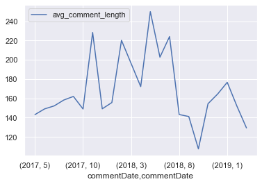

```python
comment_length_across_time = comments.groupby(by=[comments.index.year, comments.index.month]).agg(avg_comment_length = ('commentLength', 'mean')).plot()
print(comment_length_across_time)
```

## 1.2 Comment interactions made by an employee

```python
# dropping companyAlias as it is not useful for the analysis and is the same value for all employees
interactions.drop(['companyAlias'],inplace=True, axis=1)
```

```python
#changing the format of date-time to date
interactions['actionDate'] = pd.to_datetime(interactions['actionDate']).dt.date
interactions.head()
```

|  | employee | interaction | commentId | actionDate |
| --- | --- | --- | --- | --- |
| 0 | YX4 | 1 | 5909b33da2ede4000473da6f | 2017-05-03 |
| 1 | E9y | 1 | 5909b33da2ede4000473da6f | 2017-05-03 |
| 2 | mw | 1 | 5909b33da2ede4000473da6f | 2017-05-03 |
| 3 | Owv | 1 | 5909b33da2ede4000473da6f | 2017-05-03 |
| 4 | dx | 1 | 5909b33da2ede4000473da6f | 2017-05-03 |

```python
interactions.shape
```

```
(93816, 4)
```

```python
# no missing values present
interactions.isnull().values.any()
```

```
False
```

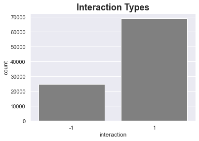

```python
#The following plot shows no employee replies(2) to a comment, they either like(1) a comment or dislike(-1) it
sns.set()
ax = sns.countplot(interactions['interaction'], color='gray')
ax.set_title('Interaction Types',fontsize = 18, fontweight='bold')
```

#### Total number of employees interacted with comments - 426

```python
unique_employees = interactions['employee'].unique().tolist()
len(unique_employees)
```

```
426
```

## 1.3 Employee votes

```python
votes.voteDate = pd.to_datetime(votes.voteDate).dt.date
total_unique = len(votes.employee.unique())
print('Total unique employees: ', total_unique)
```

```
Total unique employees:  472
```

```python
average_votes = votes.vote.mean()
average_votes
```

```
2.8495797218114083
```

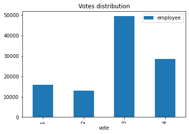

```python
votes.groupby(by='vote').count().reset_index()[['vote', 'employee']].plot(kind='bar', x='vote', y='employee', title='Votes distribution')
```

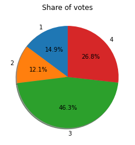

```python
pie_data = votes.groupby(by='vote').count().reset_index()[['vote', 'employee']]
plt.pie(pie_data.employee, labels=pie_data.vote, autopct='%1.1f%%', shadow=True, startangle=90)
plt.title('Share of votes')
plt.show()
```

```python
print('Earliest vote date:', votes.voteDate.min())
print('Latest vote date:', votes.voteDate.max())
```

```
Earliest vote date: 2017-05-03
Latest vote date: 2019-03-11
```

```python
votes.voteDate[0]
```

```
datetime.date(2017, 5, 3)
```

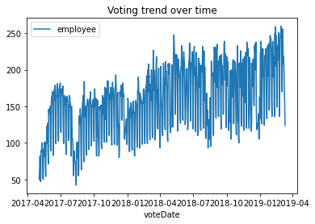

```python
# Voting trend over time
votes.groupby(by='voteDate').count().reset_index()[['voteDate', 'employee']].plot(kind='line', x='voteDate', y='employee', title='Voting trend over time')
```

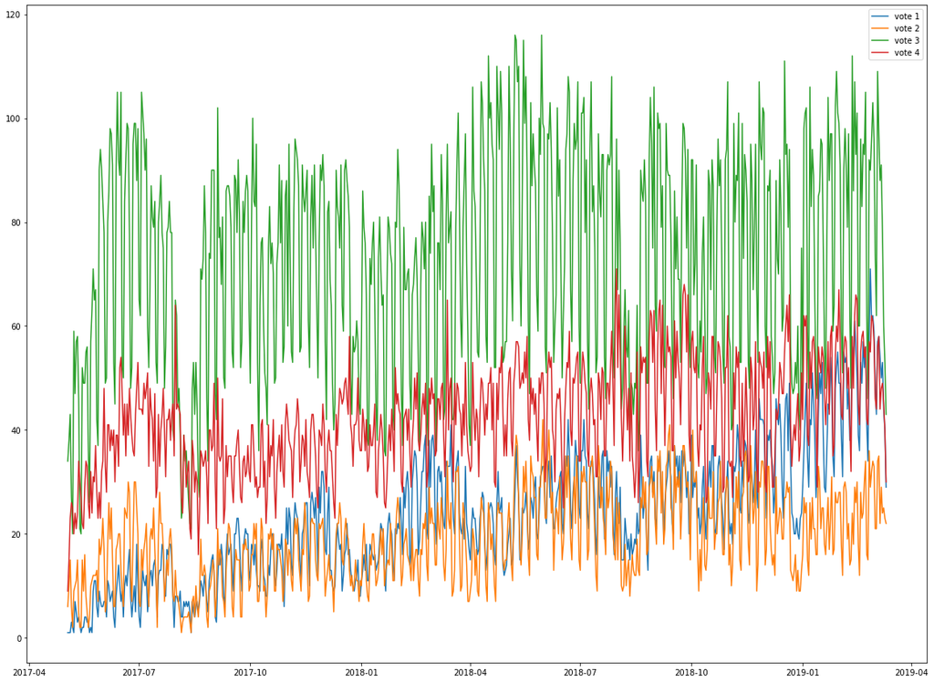

```python
# voting trend over time for each vote
vote_1 = votes[votes.vote == 1].groupby(by='voteDate').count().reset_index()[['voteDate', 'employee']]
vote_2 = votes[votes.vote == 2].groupby(by='voteDate').count().reset_index()[['voteDate', 'employee']]
vote_3 = votes[votes.vote == 3].groupby(by='voteDate').count().reset_index()[['voteDate', 'employee']]
vote_4 = votes[votes.vote == 4].groupby(by='voteDate').count().reset_index()[['voteDate', 'employee']]

f = plt.figure(figsize=(20, 15))
plt.plot(vote_1.voteDate, vote_1.employee, label='vote 1')
plt.plot(vote_2.voteDate, vote_2.employee, label='vote 2')
plt.plot(vote_3.voteDate, vote_3.employee, label='vote 3')
plt.plot(vote_4.voteDate, vote_4.employee, label='vote 4')
plt.legend()
plt.show()
```

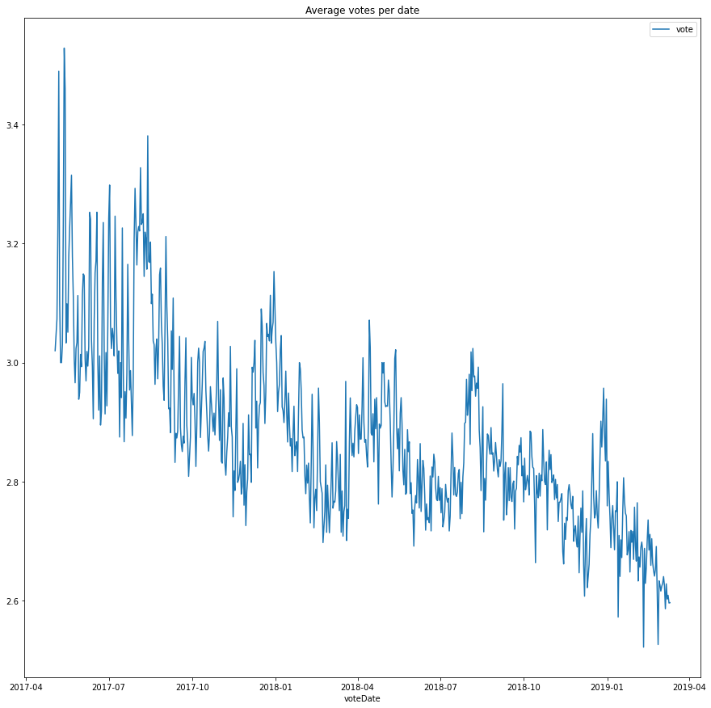

```python
# Average votes per date
votes.groupby(by='voteDate').mean().reset_index()[['voteDate', 'vote']].plot(kind='line', x='voteDate', y='vote', title='Average votes per date',figsize=(15, 15))
```

## 1.4 Whether or not an employee is absent

The scatter plot below shows the distribution of start and end dates of each case of absenteeism. The data is fractured into 3 parts: cases that start and end within June 2018, August 2018 and October 2018.

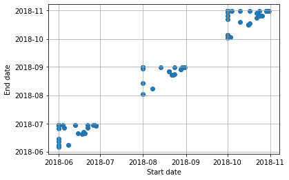

```python
absentees['from'] = pd.to_datetime(absentees['from'], format="%m/%d/%y %H:%M")
absentees['to'] = pd.to_datetime(absentees['to'], format="%m/%d/%y %H:%M")

plt.scatter(absentees['from'],absentees['to'])
plt.grid()
plt.xlabel('Start date')
plt.ylabel('End date')
```

Include new column 'length', which shows the length of each case of being absent. Add one day to the each entry in the length column, as it appears that the 'from' column shows the first day that the employee took leave, and the 'to' column shows the last day that the employee that he/she took leave.

```python
absentees['length'] = absentees['to'] - absentees['from']
absentees['length'] = absentees['length'] + timedelta(days=1)
absentees['length'] = [int(x.days) for x in absentees['length']]
```

We check the maximum length of absence among all employees, on any one occasion. We find that the maximum length of absence is 31 days.

```python
print(absentees["length"].max())
```

```
31
```

"Common sickness or accident not related to the job" is the reason given by most absent employees. All cases of "long term sick leave" last for 28 days or above.

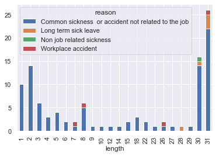

```python
absentees
absentees.pivot_table(index='length', columns='reason', aggfunc='size').plot.bar(stacked=True)
```

We group the absenteeism cases by employee and observe the behaviour of each absent employee. A large proportion of employees were absent on only one occasion in the dataset. Only 1 employee was absent on four separate occasions.

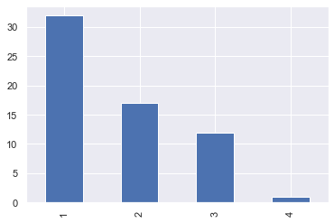

```python
abs_count = absentees.groupby('employee')['length'].count()
avg_len = absentees.groupby('employee')['length'].mean()
tot_len = absentees.groupby('employee')['length'].sum()

abs_count = pd.DataFrame(abs_count)
avg_len = pd.DataFrame(avg_len)
abs_count.reset_index(inplace=True)
avg_len.reset_index(inplace=True)
absent_emp = pd.merge(abs_count, avg_len, on='employee', how="inner")

absent_emp.columns = ['employee', 'abs_count', 'avg_len']

absent_emp['abs_count'].value_counts().plot.bar()
```

## 1.5 Interaction patterns of absentees

We are only interested in the comment interactions of the absentees and not all employees of the company, so we filter those interactions of the absentees from the interactions dataframe. What is the pattern in the interaction style of these 62 absentees?

```python
# filtering comment interactions of the absentees
unique_absentees = absentees['employee'].unique().tolist()
absentees_interactions = interactions[interactions['employee'].isin(unique_absentees)]
absentees_interactions.head()
```

|  | employee | interaction | commentId | actionDate |
| --- | --- | --- | --- | --- |
| 14 | aKP | 1 | 5909b6aca2ede4000473da72 | 2017-05-03 |
| 21 | 4qe | 1 | 5909c2dea2ede4000473db8c | 2017-05-03 |
| 23 | DW | 1 | 5909c2dea2ede4000473db8c | 2017-05-03 |
| 28 | qKO | 1 | 5909c2dea2ede4000473db8c | 2017-05-03 |
| 29 | DNY | 1 | 5909c2dea2ede4000473db8c | 2017-05-03 |

```python
# interactions of all the absentees
absentees_interactions.shape
```

```
(18614, 4)
```

#### number of absentees who actually had some sort of interactions - 56

```python
interacted_absentees = absentees_interactions['employee'].unique().tolist()
len(interacted_absentees)
```

```
56
```

```python
# sort interactions by employee and date of interaction
absentees_interactions_sorted = absentees_interactions.sort_values(['employee','actionDate'])
absentees_interactions_sorted
```

|  | employee | interaction | commentId | actionDate |
| --- | --- | --- | --- | --- |
| 59443 | 17r | 1 | 5b2bd4d238a3cd000464ad66 | 2018-06-22 |
| 61123 | 17r | 1 | 5b39ed727637a30004617f6b | 2018-07-02 |
| 72392 | 17r | 1 | 5bac1aa3a37fad00044ae67d | 2018-09-28 |
| 80584 | 17r | 1 | 5c1a1ec43d5d6d0004980848 | 2018-12-19 |
| 81187 | 17r | 1 | 5c1d3791a77bb00004fd18e4 | 2018-12-29 |
| ... | ... | ... | ... | ... |
| 27112 | zGB | 1 | 5a01c88d1f55c30004813f44 | 2017-11-08 |
| 32189 | zGB | -1 | 5a381dc28bed5a00043c9306 | 2017-12-19 |
| 77733 | zGB | 1 | 5c06aa2539e95e0004a4e567 | 2018-12-05 |
| 77847 | zGB | 1 | 5c077e8905e45d000490b30a | 2018-12-05 |
| 80938 | zGB | 1 | 5c1bfca3bc87360004b5fd79 | 2018-12-29 |

18614 rows × 4 columns

```python
# grouping the interactions of each employee chronolgically
abs_int_datewise = absentees_interactions_sorted.groupby(['employee','actionDate'])['interaction'].value_counts().unstack().fillna(0).reset_index()
```

```python
abs_int_datewise.columns.values.tolist()
```

```
['employee', 'actionDate', -1, 1]
```

```python
# renaming the columns -1 and +1
abs_int_datewise.rename(columns = {-1:'dislike_count', 1:'like_count'}, inplace = True)
```

```python
abs_int_datewise.head() #ignore the header of the index column
```

| interaction | employee | actionDate | dislike_count | like_count |
| --- | --- | --- | --- | --- |
| 0 | 17r | 2018-06-22 | 0.0 | 1.0 |
| 1 | 17r | 2018-07-02 | 0.0 | 1.0 |
| 2 | 17r | 2018-09-28 | 0.0 | 1.0 |
| 3 | 17r | 2018-12-19 | 0.0 | 1.0 |
| 4 | 17r | 2018-12-29 | 0.0 | 1.0 |

```python
# interactions of the employee "XXd"
employee_XXd = abs_int_datewise.loc[abs_int_datewise['employee'] == "XXd"]
```

```python
# instances of absence by employee "XXd"
absentees.loc[absentees['employee'] == "XXd"]
```

|  | employee | companyAlias | from | to | reason | length |
| --- | --- | --- | --- | --- | --- | --- |
| 17 | XXd | C1 | 2018-10-01 00:10:00 | 2018-10-22 00:10:00 | Common sickness or accident not related to th... | 22 |
| 50 | XXd | C1 | 2018-08-01 00:08:00 | 2018-08-31 00:08:00 | Common sickness or accident not related to th... | 31 |
| 86 | XXd | C1 | 2018-06-01 00:06:00 | 2018-06-30 00:06:00 | Common sickness or accident not related to th... | 30 |

#### Result : Unable to find any significant pattern with absentees' interaction to comments and leave taking